# P4 Actividades de estudiantes Universitarios de la UTEC durante las Vacaciones en pandemia

## Introducción

El siguiente informe refleja los datos proporcionados por los estudiantes de la UTEC (Universidad de Ingeniera y Tecnología) a través de una encuesta realizada por Google Forms, con finalidad de poder saber como se desarrolla la población Utecsina cuando el estudio pasa a segundo plano.

En esta oportunidad se va a realizar el análisis de las graficas y tablas, se buscara una realción pertinente y que colabore al objetivo de el proyecto, ademas de el uso de variables aleatorias para poder precedir situaciones. El análisis respectivo sera sobre de 29 variables y 157 observaciones conseguidas.

## Marco teorico

Población objetivo: Estudiantes de la Universidad de Ingeniería y Tecnología (UTEC)

Tipo de muestreo: Muestreo aleatorio simple

Sesgo: sesgo de selección

Unidades muéstrales: 157 observaciones

Interesados: Alumnos en general

Variables: Variables de DataFrame de información de los estudiantes

## Recordatorio de Objetivo

Brindar información relevante de las diferentes actividades que realizan los estudiantes de la UTEC en una semana regular durante las vacaciones en un contexto de pandemia.

## Importancia

Con el proyecto podremos encontrar soluciones a problemas de rendimiento academico, al ver el comportamiento que tienen en dias donde el estudio no es prioridad, ademas de las actividades que tienden a realizar y como la pandemia ha afectado a las actividades de los estudiantes durante el periodo vacacional.

Diagrama de Gantt de nuestros pasos a seguir en el proyecto:

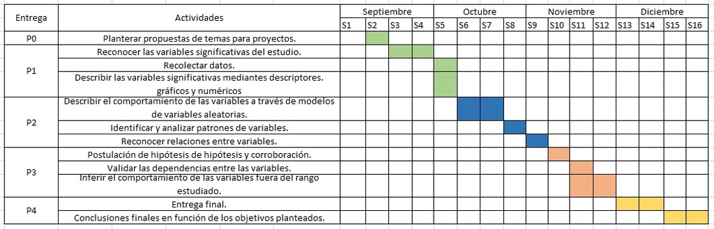

## Obtencion de observaciones

Las observaciones, tal dicho antes se consiguieron a traves de Google Forms

[figure not shown]

## Variables

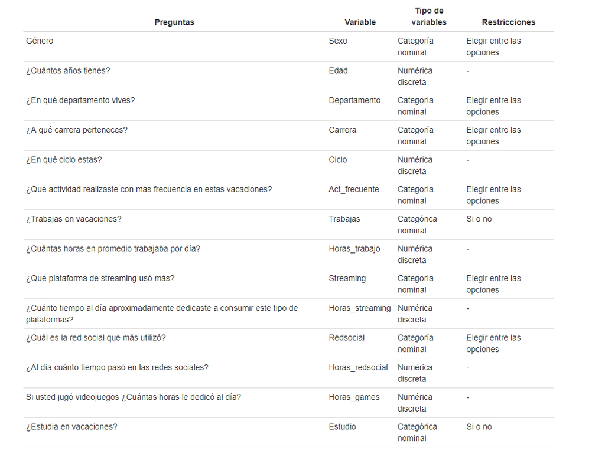

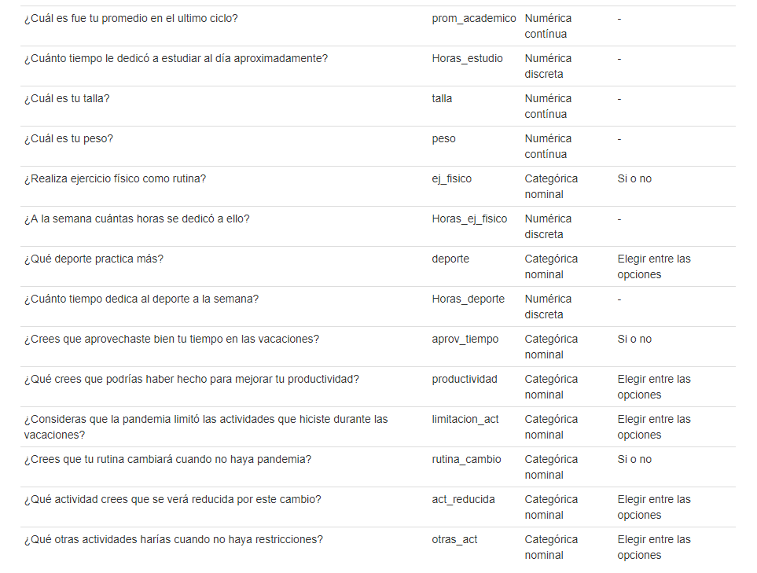

## Limpieza de datos

En primer lugar se elimino las primeras 2 columnas, ya que estas contenian el correo y la fecha de entrega de la observacion, cuales eran irrelevantes para nuestra investigacion.

Se cambio el nombre a las 28 variables para hacer el trabajo mas simple, ademas se agrego una variable numerica al final que sirvio como referencia a la hora de editar el DataFrame.

Y a partir con esa variable y con la funcion filter, se hallaron los valores erroneos que los encuestados colocaron y se reemplazaron a valores mas coherentes, aunque algunas excepciones hacian que la observacion sea invalida para nuestro analisis.

Dandonos como resultado 154 observaciones validas y 29 variables.

## Limpieza de datos (Codigo)

```r
DF = DF[,-1:-2]
names(DF)<-c("Sexo","Edad","Departamento","Carrera","Ciclo","Act_frecuente","Trabajas","Horas_trabajo","Streaming","Horas_streaming","Redsocial","Horas_redsocial","Horas_games","Estudio","prom_academico",
             "Horas_estudio","talla","peso","ej_fisico","Horas_ej_fisico","deporte","Horas_deporte","aprov_tiempo","productividad","limitacion_act","rutina_cambio","act_reducida","otras_act")
numero<-c(1:157)
DF<-cbind(DF,numero)

DF[41,18]=63
DF[50,5]=1
DF[130,5]=1
DF[153,5]=3
DF[33,18]=58

i=1:157
DF[1:157,17] <- ifelse(DF[i,17]<2,DF[i,17]*100,DF[i,17])
DF=DF[-119,]
DF=DF[-99,]
DF=DF[-97,]
dim(DF)
```

```
## [1] 154  29
```

## Resultados principales de la encuesta: Género de los encuestados

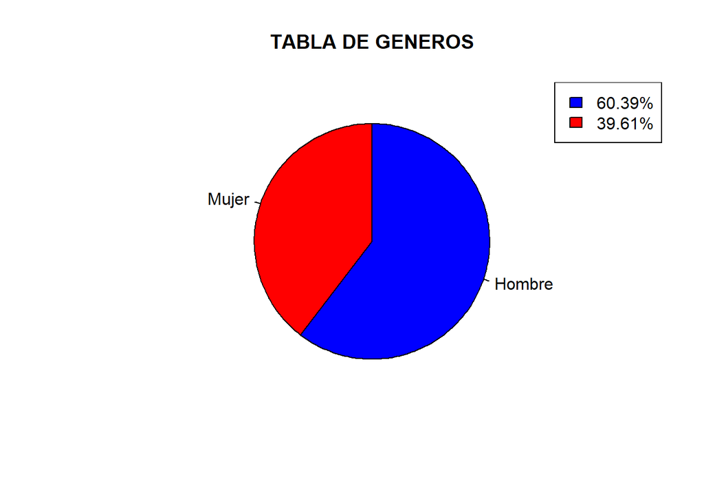

```r
colores <- c("blue","red")
pie(round((table(DF$Sexo)/sum(table(DF$Sexo)))*100,2), clockwise = TRUE , col = colores , main= "TABLA DE GENEROS")
legend("topright", c("60.39%","39.61%"),fill=colores)
```

## Edad de los encuestados

```r
table(DF$Sexo,DF$Edad)
```

```
##
##          17 18 19 20 21 22 23 24 25 26 28
##   Hombre  2 19 28 18  7  7  4  2  2  3  1
##   Mujer   4 17 15 14  6  3  2  0  0  0  0
```

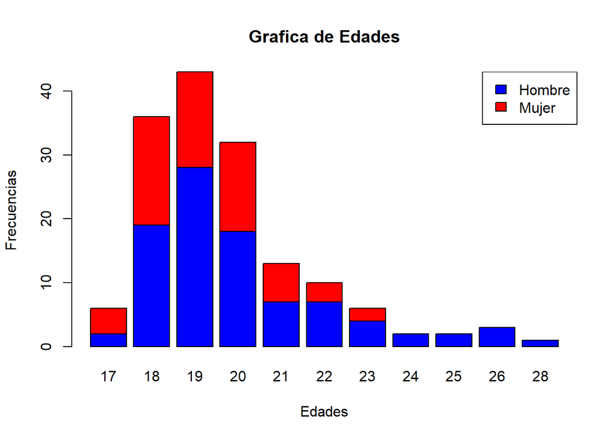

```r
x1<-table(DF$Sexo,DF$Edad)
colores1=c("blue","red","yellow","green","orange","brown","violet","black","pink","gray","purple","magenta","beige","aquamarine3","aliceblue","antiquewhite2","darkgoldenrod","darkolivegreen")
barplot(x1,xlab = "Edades",ylab="Frecuencias" ,main="Grafica de Edades",col = colores1)
legend("topright", c("Hombre","Mujer"),fill=colores)
```

## Ciclo academico actual de los encuestados

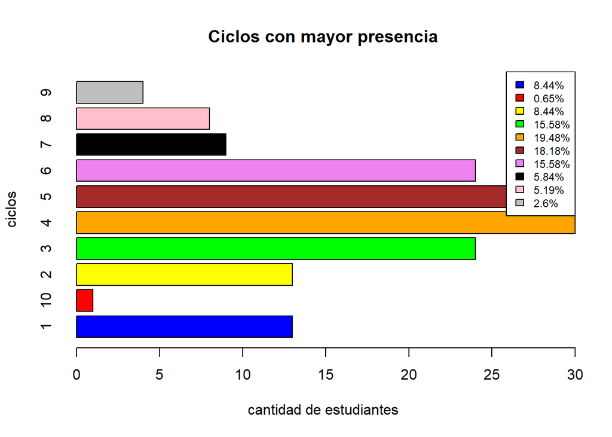

```r
barplot(table(DF$Ciclo),ylab="ciclos", xlab = "cantidad de estudiantes",main = "Ciclos con mayor presencia",col = colores1,horiz = TRUE)
legend("topright",c("8.44%","0.65%","8.44%","15.58%","19.48%","18.18%","15.58%","5.84%","5.19%","2.6%"),cex=0.75,fill=colores1)
```

## Departamento de proveniencia de los encuestados

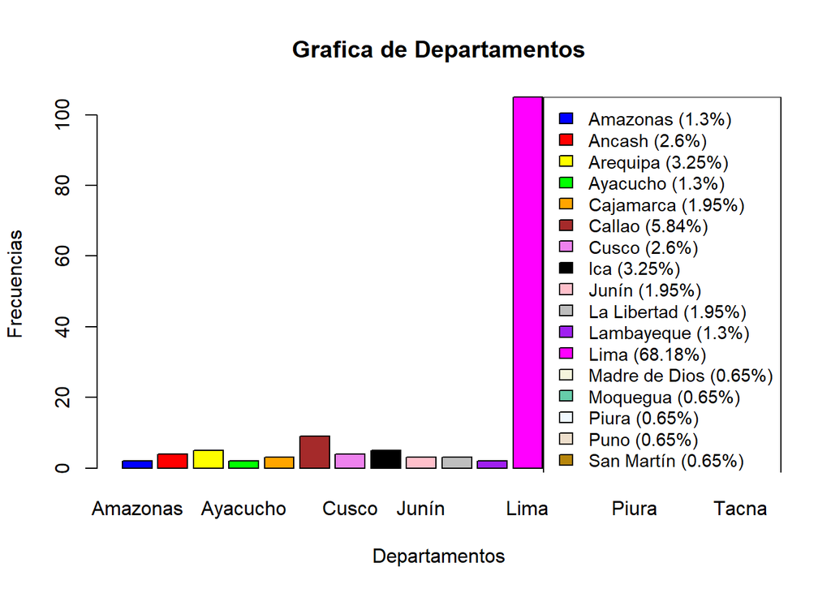

```r
x2<-table(DF$Departamento)
barplot(x2,xlab = "Departamentos",ylab="Frecuencias" ,main="Grafica de Departamentos",col = colores1)
legend("topright",c("Amazonas (1.3%)","Ancash (2.6%)","Arequipa (3.25%)","Ayacucho (1.3%)","Cajamarca (1.95%)","Callao (5.84%)","Cusco (2.6%)","Ica (3.25%)","Junín (1.95%)","La Libertad (1.95%)","Lambayeque (1.3%)","Lima (68.18%)","Madre de Dios (0.65%)","Moquegua (0.65%)","Piura (0.65%)","Puno (0.65%)","San Martín (0.65%)","Tacna (1.3%)"),cex = 0.9 ,fill = colores1)
```

## Carrera universitaria de los encuestados

```r
tablaCar <- as.data.frame(table(Carrea=DF$Carrera))
transform(tablaCar,FreqAc= cumsum(Freq),Rel= round(prop.table(Freq),3),RelAc=round(cumsum(prop.table(Freq)),3))
```

| Carrea | Freq | FreqAc | Rel | RelAc |
| --- | --- | --- | --- | --- |
| Ambiental | 6 | 6 | 0.039 | 0.039 |
| Bioingeniería | 22 | 28 | 0.143 | 0.182 |
| Civil | 30 | 58 | 0.195 | 0.377 |
| CS | 11 | 69 | 0.071 | 0.448 |
| Electrónica | 9 | 78 | 0.058 | 0.506 |
| Energia | 5 | 83 | 0.032 | 0.539 |
| Industrial | 36 | 119 | 0.234 | 0.773 |
| Mecanica | 8 | 127 | 0.052 | 0.825 |
| Mecatrónica | 22 | 149 | 0.143 | 0.968 |
| Química | 5 | 154 | 0.032 | 1.000 |

## Actividades de los encuestados

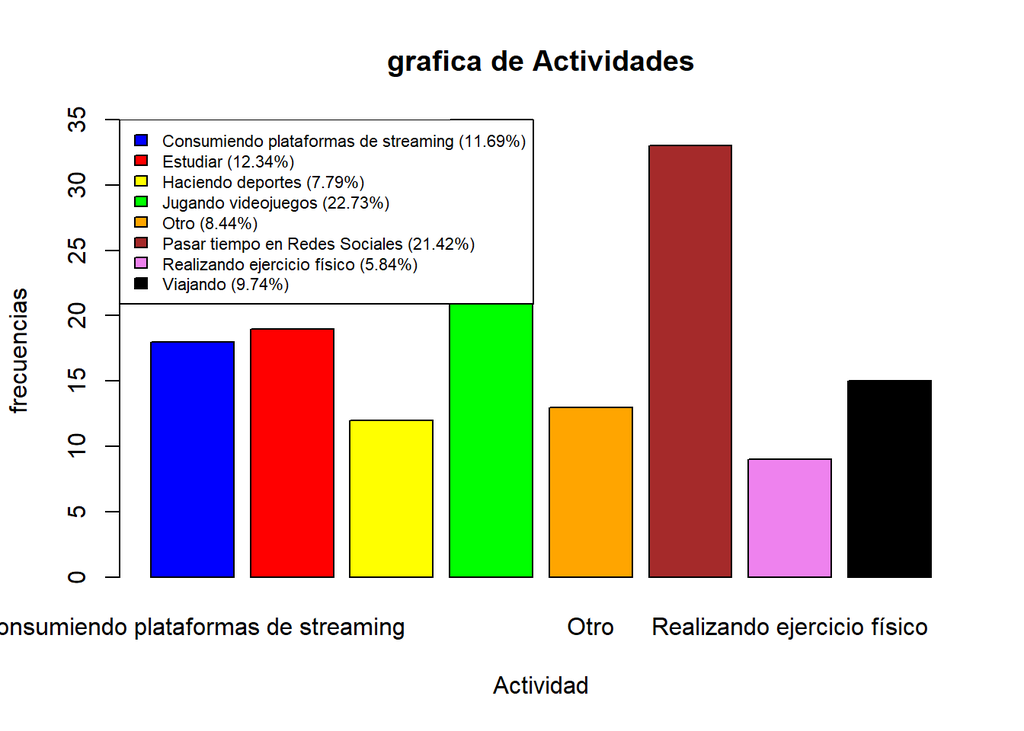

```r
x3<-table(DF$Act_frecuente)
barplot(x3,xlab="Actividad",ylab = "frecuencias", main = "grafica de Actividades",col = colores1)
legend("topleft", c("Consumiendo plataformas de streaming (11.69%)","Estudiar (12.34%)","Haciendo deportes (7.79%)","Jugando videojuegos (22.73%)","Otro (8.44%)","Pasar tiempo en Redes Sociales (21.42%)","Realizando ejercicio físico (5.84%)","Viajando (9.74%)"),cex = 0.7,fill=colores1)
```

## ¿Los encuestados hacen ejercicio físico?

```r
round((table(DF$ej_fisico)/sum(table(DF$ej_fisico)))*100,2)
```

```
##
##    No    Si
## 59.09 40.91
```

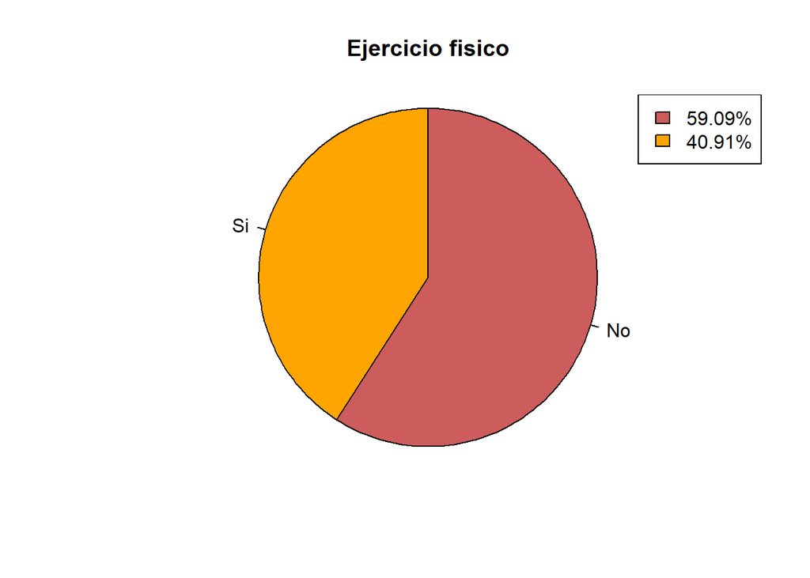

```r
colores <- c("indianred","orange")
pie(round((table(DF$ej_fisico)/sum(table(DF$ej_fisico)))*100,2), clockwise = TRUE , col = colores , main= "Ejercicio fisico",radius = 1
    )
legend("topright", c("59.09%","40.91%"),fill=colores)
```

## ¿Los encuestados trabajan en vacaciones?

```r
round((table(DF$Trabajas)/sum(table(DF$Trabajas)))*100,2)
```

```
##
##    No    Sí
## 65.58 34.42
```

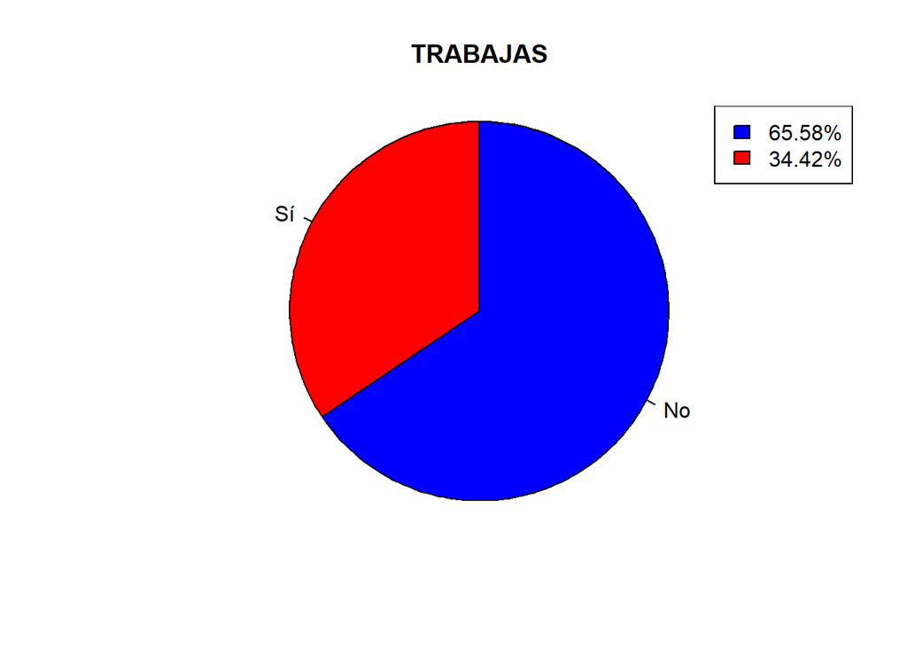

```r
colores <- c("blue","red")
pie(round((table(DF$Trabajas)/sum(table(DF$Trabajas)))*100,2), clockwise = TRUE , col = colores , main= "TRABAJAS",radius = 1
)
legend("topright", c("65.58%","34.42%"),fill=colores)
```

## ¿Los encuestados estudian en vacaciones?

```r
round((table(DF$Estudio)/sum(table(DF$Estudio)))*100,2)
```

```
##
##    No    Sí
## 25.32 74.68
```

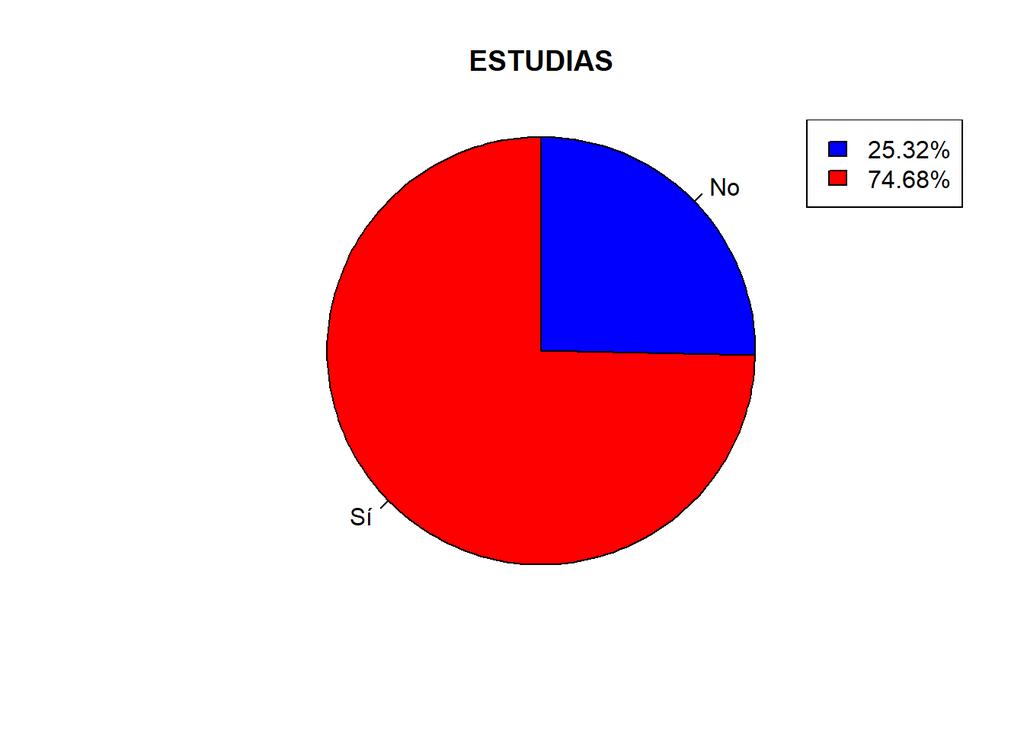

```r
colores <- c("blue","red")
pie(round((table(DF$Estudio)/sum(table(DF$Estudio)))*100,2), clockwise = TRUE , col = colores , main= "ESTUDIAS",radius = 1
)
legend("topright", c("25.32%","74.68%"),fill=colores)
```

## Consumo de plataformas de streaming

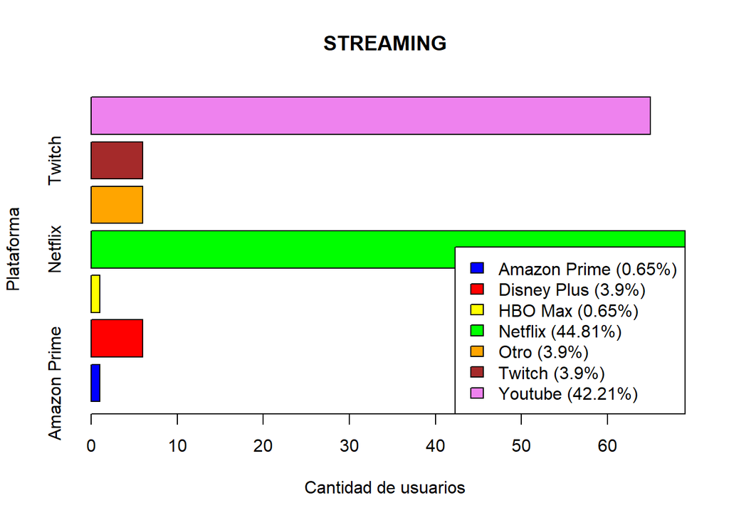

```r
X5<-table(DF$Streaming)
barplot(X5,xlab="Cantidad de usuarios",ylab="Plataforma",main="STREAMING",col=colores1,horiz=TRUE)
legend("bottomright", c("Amazon Prime (0.65%)","Disney Plus (3.9%)","HBO Max (0.65%)","Netflix (44.81%)","Otro (3.9%)","Twitch (3.9%)","Youtube (42.21%)"),cex = 1,fill=colores1)
```

## Análisis de las gráficas

La mayoria de encuestados son hombres y la mayoria dedican mayor tiempo en las vacaciones a jugar videojuegos (22.73%), este seguido del uso de las redes sociales (21.43%).

Como se preveía, la gran mayoría de encuestados provienen de la capital, Lima (68.18%)

la gráfica de si realizan ejercicio físico nos muestra que hay mas gente que no lo practica de la que practica, y de ese porcentaje que si lo practica, una fracción dedica la mayoría de su tiempo en las vacaciones al ejercicio físico.

las aplicaciones mas populares para el consumo de plataformas de streaming, como era de esperarse son Netflix (44.81%) y YouTube (42.21%)

## Análisis de las gráficas

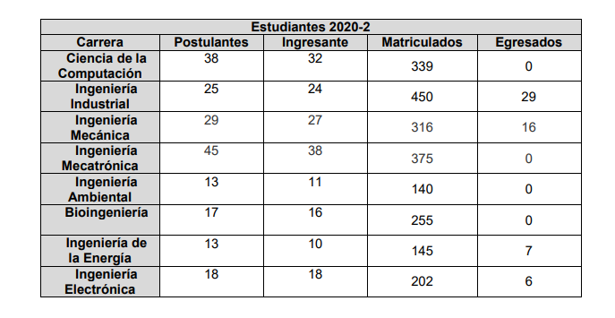

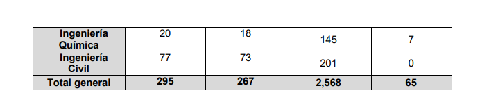

## Descriptores Numéricos

La primera tabla corresponde a los datos de la talla, peso, edad y promedio académico entregadas por los encuestados. a partir de ello se calculo también el indice de masa corporal (IMC).

```
##          talla  peso       IMC  edad prom. Academico
## media   167.71 66.78 23.660000 19.75         14.1400
## mediana 168.00 65.00 23.053011 19.00         15.0000
## SD        8.22 12.43  3.550000  1.97          4.6000
## rango    41.00 65.40 20.333330 11.00         19.5000
## RIC      12.00 15.75  3.802257  2.00          2.4375
```

Y este seria el coeficiente de variabilidad de las variables

```r
Coeff_val <- c(df[3,1],df[3,2],df[3,3],df[3,4],df[3,5])/c(df[1,1],df[1,2],df[1,3],df[1,4],df[1,5])
round(Coeff_val,3)
```

```
## [1] 0.049 0.186 0.150 0.100 0.325
```

## Descriptores numéricos

```
##         Trab. Stream   RS Games Estudio Fisico Deporte
## media    6.08   3.08  3.1  1.69    4.10   5.59    4.27
## mediana  6.00   3.00  3.0  1.00    4.00   5.00    3.00
## SD       2.16   2.16  2.3  1.74    2.19   4.47    4.13
## rango   10.00  18.00 18.0  9.00   11.00  22.00   23.00
## RIC      4.00   2.00  2.0  3.00    2.50   4.50    4.00
```

Y este seria el coeficiente de varaibilidad de las variables de la tabla

```r
Coeff_val <- c(df[3,1],df[3,2],df[3,3],df[3,4],df[3,5],df[3,6],df[3,7])/c(df[1,1],df[1,2],df[1,3],df[1,4],df[1,5],df[1,6],df[1,7])
round(Coeff_val,3)
```

```
## [1] 0.355 0.701 0.742 1.030 0.534 0.800 0.967
```

## Análisis de los descrip. numéricos

Con respecto a la primera tabla, se puede divisar que la talla de los encuestados es que menos varia, gracias a que su Coeficiente de variabilidad es el de menor valor de la tabla.

La media del promedio académico es de 14.14, cual entre comillas se podría decir que esta bien pero si vemos el coeficiente de variabilidad, nos percatamos que es un valor engañoso para mostrar, no refleja el rendimiento total de los encuestados en el ultimo ciclo, tal ves este valor de media se vea afectado por los que encuestaron con promedio igual a 0, ya que según la encuesta los que colocaron ese numero son los de primer ciclo; Tambien explica de porque el coeficiente de variabilidad es muy alta.

## Análisis de los descrip. numéricos

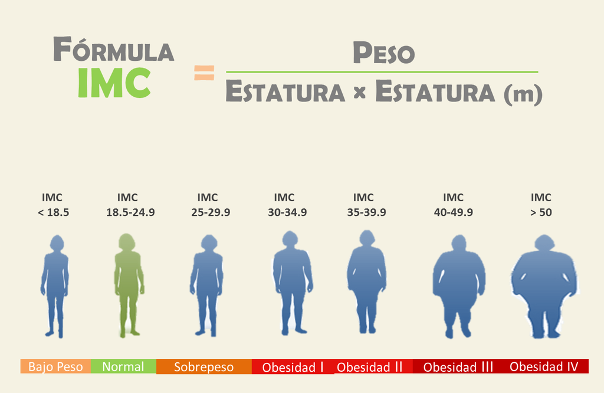

## Análisis de los descrip. numéricos

Respecto a la tabla numero 2, se puede ver que la media mas alta es la de horas de trabajo por día, ademas teniendo un coeficiente de variabilidad bajo, cual indica que los que respondieron tienen similares horas de trabajo, claramente de los que trabajan en vacaciones (34.42% de los encuestados).

Se aprecia que el coeficiente de variabilidad de las horas de videojuegos por día es muy alta, cual dice que los encuestados que dedican su tiempo a eso, o tienden a jugar un rato de su tiempo, o prácticamente juegan todo el día, aprovechando al máximo su tiempo en recrearse.

Los promedios de horas de estudio, de deporte y de ejercicio físico son similares, pero se diferencian por su coeficiente de variabilidad, siendo el las horas de estudio con un coeficiente mas bajo de los 3 mencionados, cual menciona que los encuestados estudian cantidad de horas similares por día, pero el ejercicio físico y los deportes se pueden inferir 2 cosas como en los videojuegos (en mayor o menor medida): o dedican un rato de su tiempo, o prácticamente lo dedican todo el día.

## Variables aleatorias

Teniendo un nivel de confianza del 95% y un error del 5%, ademas de 154 grados de libertad. El intervalo de confianza de la media, segun la tabla del sigma conocido seria de esta forma:

| Tipo | n < 30 | n > 30 |
| --- | --- | --- |
| $\sigma$ conocido | N(1-a/2,0,1) | N(1-a/2,0,1) |
| $\sigma$ desconocido | t(1-a/2,n-1) | N(1-a/2,0,1) |

$$\bar{x}-N(1-\frac{\alpha}{2})\frac{S}{\sqrt{n}}
\leq \mu \leq
\bar{x}+N(1-\frac{\alpha}{2})\frac{S}{\sqrt{n}}$$

## VAD Estudio

Esta variable de la encuesta obtuvo 154 respuestas validas, una independiente de otra y tienen la misma probabilidad de ser seleccionadas.

Al considerarse que es una distribución binomial con parámetros n y P, El éxito sera la probabilidad de que un estudiante haya estudiado en vacaciones con valor P, y fracaso el estudiante que no haya estudiado en vacaciones, con valor 1-P, y n la cantidad total de observaciones validas.

```r
#exito
P <- nrow(filter(DF,DF$Estudio=="Sí"))/nrow(DF)
P
```

```
## [1] 0.7467532
```

```r
#numero total de observaciones validas
n <- nrow(DF)
x <- 0:nrow(DF)
#media y varianza
m1 <- n*P
m1
```

```
## [1] 115
```

```r
v1 <- n*P*(1-P)
v1
```

```
## [1] 29.12338
```

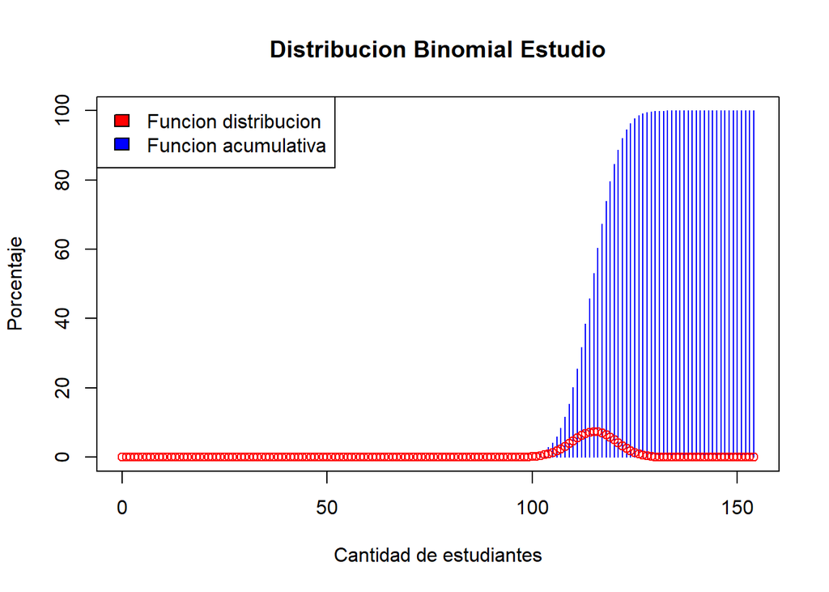

Al acercar la grafica se puede observar:

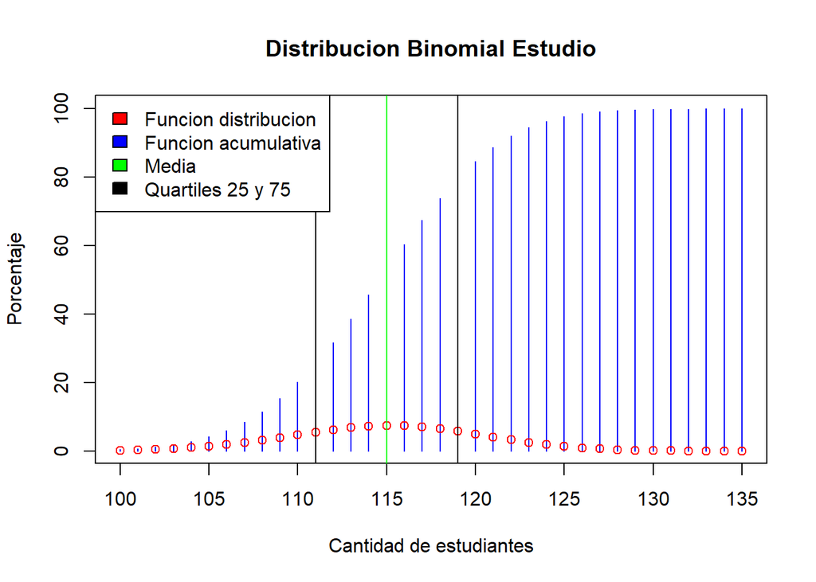

Esto significa que de 154 estudiantes, para la funcion de distribución binomial, muestra la probabilidad de que exactamente esa cantidad de estudiantes hayan estudiado en las vacaciones, mientras tanto la función acumulada representa la probabilidad de que minimo o maximo X estudiantes hayan estudiado en las vacaciones.

## Inferencial Estudio

Teniendo un nivel de confianza del 95% y un error del 5%, ademas de 154 grados de libertad y siendo X: cantidad de estudientes universitarios que estudiaron en la pandemia de 154 estudiantes; el intervalo de confianza de la media:
$$\bar{x}-t(1-\frac{\alpha}{2};n-1)\frac{S}{\sqrt{n}}
\leq \mu \leq
\bar{x}+t(1-\frac{\alpha}{2};n-1)\frac{S}{\sqrt{n}}$$

Siendo S la desviacion estandar que es la raiz de la varianza y barra X la media ya calculadas.

```
## [1] 114.1409
```

```
## [1] 115.8591
```

Obteniendo que el intervalo de la media es: $114.14 \leq \mu \leq 115.86$

Respecto a la proporcion, su intervalo de confianza es:
$$P-Z(1-\frac{\alpha}{2})*\sqrt{\frac{P(1-P)}{n}}
\leq \pi \leq
P+Z(1-\frac{\alpha}{2})*\sqrt{\frac{P(1-P)}{n}}$$

```
## [1] 0.6780704
```

```
## [1] 0.8154361
```

Obteniendo que el intervalo de la proporcion es: $0.68 \leq \pi \leq 0.82$

Por ultimo, el intervalo de confianza de la varianza es:
$$\frac{(n-1)S^2}{X^2(1-\frac{\alpha}{2};n-1)} \leq
\sigma^2 \leq \frac{(n-1)S^2}{X^2(\frac{\alpha}{2};n-1)}$$

```
## [1] 23.55878
```

```
## [1] 36.93337
```

Obteniendo que el intervalo de la varianza es: $23.56 \leq \sigma^2 \leq 36.93$

Observaciones:

- Se puede observar que la probabilidad de que exactamente de 0 a 100 estudiantes (X=1;X=2;X=3; etc) hayan estudiado en pandemia es basicamente nula, y esta nulidad se aplica tambien aproximandamente en el valor de 130 hasta llegar a n=154.
- El intervalo de confianza de la proporcion indica que las probabilidades de que un alunmo haya estudiado en vacaciones varia mucho con respecto al valor muestral que es del 0.7468, cual el rango que ocupa el intervalo es de 0.1373, que considerando que es una probabilidad, es mucho error.

## VAD Horas de streaming

La variable “Horas_streaming” ha sido obtenida de las respuestas de una encuesta, en donde estas respuestas son independientes y tienen la misma probabilidad de ser seleccionadas.

CRITERIO DE ANÁLISIS: Se considero a esta variable como la distribución binomial. La variable “Horas_streaming” tiene dos posibles resultados, una que se identifica como éxito y otra como fracaso. Estos resultados tienen la misma probabilidad de ser elegidos.

Definimos:

Éxito al estudiante que decido MENOS de tres horas a consumir plataformas de streaming.

Fracaso al estudiante que dedicó IGUAL O MÁS de tres horas a consumir plataformas de streaming.

```r
P2 <- nrow(filter(DF,DF$Horas_streaming < 3))/nrow(DF)
P2
```

```
## [1] 0.4480519
```

```r
#media y varianza
m2 <- n*P2
m2
```

```
## [1] 69
```

```r
v2 <- n*P2*(1-P2)
v2
```

```
## [1] 38.08442
```

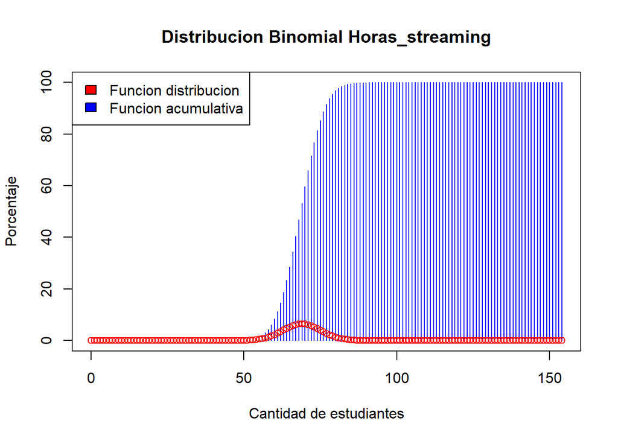

Al acercar la grafica se puede observar:

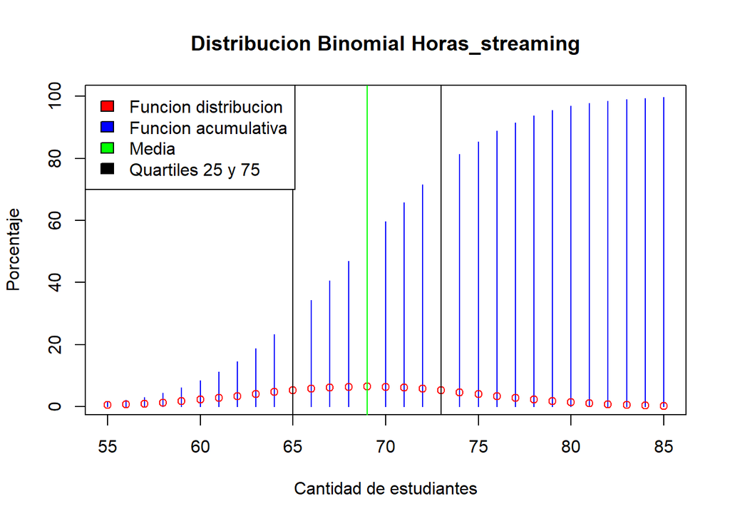

Esto significa que de 154 estudiantes, para la funcion de distribucion binomial, muestra la probabilidad de que exactamente esa cantidad de estudiantes hayan visto menos de 3 horas en plataformas de streaming al dia, mientras tanto la funcion acumulada representa la probabilidad de que minimo o maximo X estudiantes hayan visto menos de 3 horas en plataformas de streaming al dia.

## Inferencial Horas de streaming

Teniendo un nivel de confianza del 95% y un error del 5%, ademas de 154 grados de libertad y siendo X: cantidad de estudientes universitarios que hayan visto menos de 3 horas en plataformas de streaming de 154 estudiantes; el intervalo de confianza de la media:
$$\bar{x}-t(1-\frac{\alpha}{2};n-1)\frac{S}{\sqrt{n}}
\leq \mu \leq
\bar{x}+t(1-\frac{\alpha}{2};n-1)\frac{S}{\sqrt{n}}$$

Siendo S la desviacion estandar que es la raiz de la varianza y barra X la media ya calculadas.

```
## [1] 68.01755
```

```
## [1] 69.98245
```

Obteniendo que el intervalo de la media es: $68.02 \leq \mu \leq 69.98$

Respecto a la proporcion, su intervalo de confianza es:
$$P-Z(1-\frac{\alpha}{2})*\sqrt{\frac{P(1-P)}{n}}
\leq \pi \leq
P+Z(1-\frac{\alpha}{2})*\sqrt{\frac{P(1-P)}{n}}$$

```
## [1] 0.3695101
```

```
## [1] 0.5265938
```

Obteniendo que el intervalo de la proporcion es: $0.37 \leq \pi \leq 0.53$

Por ultimo, el intervalo de confinaza de la varianza es:
$$\frac{(n-1)S^2}{X^2(1-\frac{\alpha}{2};n-1)} \leq
\sigma^2 \leq \frac{(n-1)S^2}{X^2(\frac{\alpha}{2};n-1)}$$

```
## [1] 30.80764
```

```
## [1] 48.29748
```

Obteniendo que el intervalo de la varianza es: $30.81 \leq \sigma^2 \leq 48.3$

Observaciones:

- Se puede observar que la probabilidad de que exactamente de 0 a 50 estudiantes (X=1;X=2;X=3; etc), tal como el caso anterior, que hayan visto menos de 3 horas de plataformas de streaming es basicamente nula, y esta nulidad se aplica tambien aproximandamente en el valor de X=80 hasta llegar al total.
- El intervalo de confianza de la proporcion tiene una amplitud similar al caso anterior, esta proporcion indicando que las probabilidades de que un alunmo haya hayan visto menos de 3 horas de plataformas de streaming sea el valor muestral de 0.4481, cual el rango que ocupa el intervalo es de 0.1571.

## V.A.D. Horas_redsocial

La variable “Horas_redsocial” ha sido obtenida de las respuestas de una encuesta, en donde estas respuestas son independientes y tienen la misma probabilidad de ser seleccionadas.

CRITERIO DE ANÁLISIS

Definimos:

Éxito al estudiante que dedicó MENOS de dos horas a consumir cualquier red social.

Fracaso al estudiante que dedicó IGUAL O MÁS de de dos horas a consumir cualquier red social.

```r
P3 <- nrow(filter(DF, DF$Horas_redsocial < 2))/nrow(DF)
P3
```

```
## [1] 0.2077922
```

```r
#media y varianza
m3 <- n*P3
m3
```

```
## [1] 32
```

```r
v3 <- n*P3*(1-P3)
v3
```

```
## [1] 25.35065
```

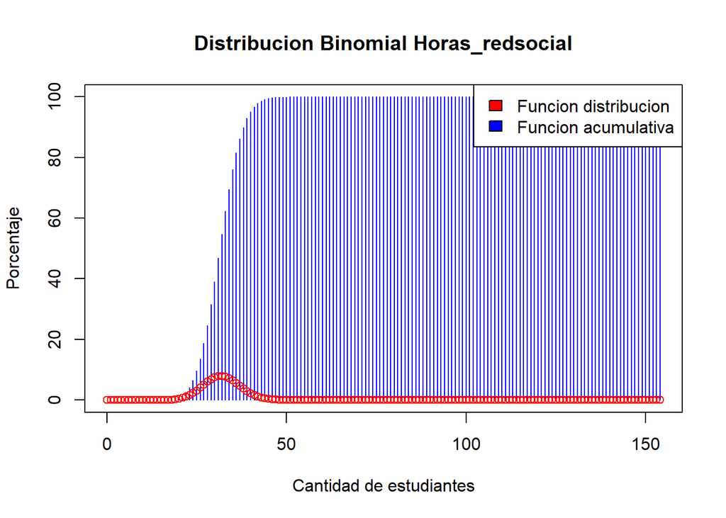

Al acercar la grafica se puede observar:

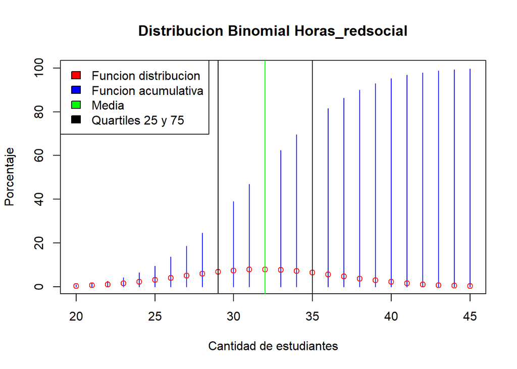

## Inferencial Horas_redsocial

Siendo S la desviación estandar que es la raíz de la varianza y barra X la media ya calculadas.

```
## [1] 31.19845
```

```
## [1] 32.80155
```

obteniendo que el intervalo de la media es: $31.2 \leq \mu \leq 32.8$

Respecto a la proporción, su intervalo de confianza es:
$$P-Z(1-\frac{\alpha}{2})*\sqrt{\frac{P(1-P)}{n}}
\leq \pi \leq
P+Z(1-\frac{\alpha}{2})*\sqrt{\frac{P(1-P)}{n}}$$

```
## [1] 0.1543048
```

```
## [1] 0.2612796
```

Por ultimo, el intervalo de confianza de la varianza es:
$$\frac{(n-1)S^2}{X^2(1-\frac{\alpha}{2};n-1)} \leq
\sigma^2 \leq \frac{(n-1)S^2}{X^2(\frac{\alpha}{2};n-1)}$$

```
## [1] 20.50691
```

```
## [1] 32.14891
```

Obteniendo que el intervalo de la varianza es: $20.51 \leq \sigma^2 \leq 32.15$

Observaciones:

- Se puede observar que la probabilidad de que exactamente de 0 a 20 estudiantes (X=1,X=2,X=3, etc) que hayan visto menos de 2 horas consumiendo redes sociales es básicamente nula, y esta nulidad se aplica también aproximadamente en el valor de X=50 hasta llegar al total.
- El intervalo de confianza de la proporción tiene una amplitud de 0.107, esta proporción indicando que las probabilidades de que un estudiante haya consumido menos de 2 horas de redes sociales, su valor muestral siendo de 0.2078.

## Propuestas de hipótesis:

### Hipótesis 1:

### Hipótesis planteadas:

1.- A mayor cantidad de horas de estudio mejores promedios.

2.- Los estudiantes que estudian al menos 1 hora diaria tienen un promedio de mayor o igual 14.

3.- Los estudiantes estudian en verano.

### Parámetros del estudio:

- Confianza: 95%
- Significancia: 5%
- Todas nuestras hipótesis utilizarán como modelo a la t-student porque no tenemos los datos poblacionales requeridos.

### Parámetros de la hipótesis 1:

- Variable: prom_academico
- Prueba de hipótesis: Unilateral izquierda
- Estimador puntual: Media
- Modelo: t-Student
- *Ho*= El promedio tiene un valor mayor o igual 14.
- *H1*= El promedio tiene un valor menor a 14.

### Intervalo de confianza

```
## [1] 13.40461
```

```
## [1] 14.13669
```

```
## [1] 14.86877
```

### *Resultados de la hipótesis 1*

```r
t0<-qt(alfa,df=n-1)
t0
```

```
## [1] -1.654874
```

```r
tc <- ((media-14)/(s/sqrt(n)))
tc
```

```
## [1] 0.3688671
```

```r
# Aceptamos el H0
```

- Estadístico de prueba : 0.3689
- Valor crítico: -1.6549
- Prueba de hipótesis Unilateral izquierda:

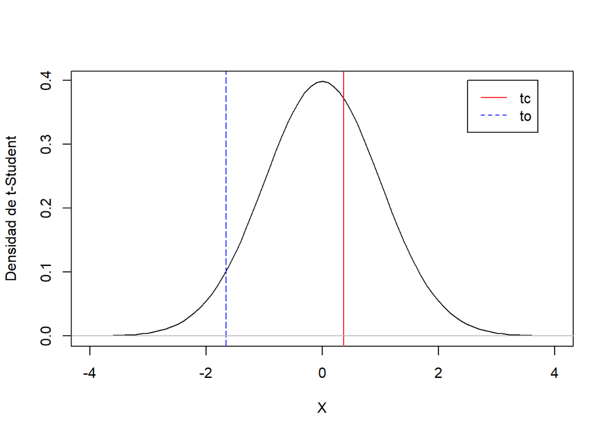

```r
X <- seq(-4, 4, by = 0.1)
plot(X, dt(X,df=n-1), type = "l",ylab="Densidad de t-Student")
abline(v=tc, lty = c(1,2), col = "red")
abline(v=t0, lty = c(5,5), col = "blue")
abline(h = 0, col = "gray")
legend(2.5,0.4,c("tc","to"),col=c("red","blue"), lty = c(1,2))
```

### Hipótesis 2:

## Hipótesis planteadas:

Realizamos un resumen para las tallas de los estudiantes

```
##    Min. 1st Qu.  Median    Mean 3rd Qu.    Max.
##   146.0   162.0   168.0   167.7   174.0   187.0
```

### Parámetros del estudio:

- Nivel de confianza= 95%
- error=5%
- Variable: DF$talla
- Prueba de hipótesis: unilateral izquierda
- Estimador puntual: Media

Hipótesis nula: El promedio de talla de los estudiantes de UTEC es mayor o igual  
168 cm

Hipótesis alternativa: El promedio de talla de los estudiantes de UTEC es menor a 168 cm

$H_0 :\mu >=$ 168 cm

$H_a :\mu <$ 168 cm

### Resultados de la hipótesis

```r
media<-mean(DF$talla, na.rm = TRUE)
s<-sd(DF$talla, na.rm = TRUE)
n<-nrow(DF)-sum(!complete.cases(DF$talla))
sig<-0.05
to<-qt(sig,n-1)
to
```

```
## [1] -1.654874
```

```r
tc <- (media-168)/(s/sqrt(n))
tc
```

```
## [1] -0.4314772
```

- Estadístico de prueba : -0.4315
- Valor crítico: -1.6549
- Prueba de hipótesis: unilateral izquierda

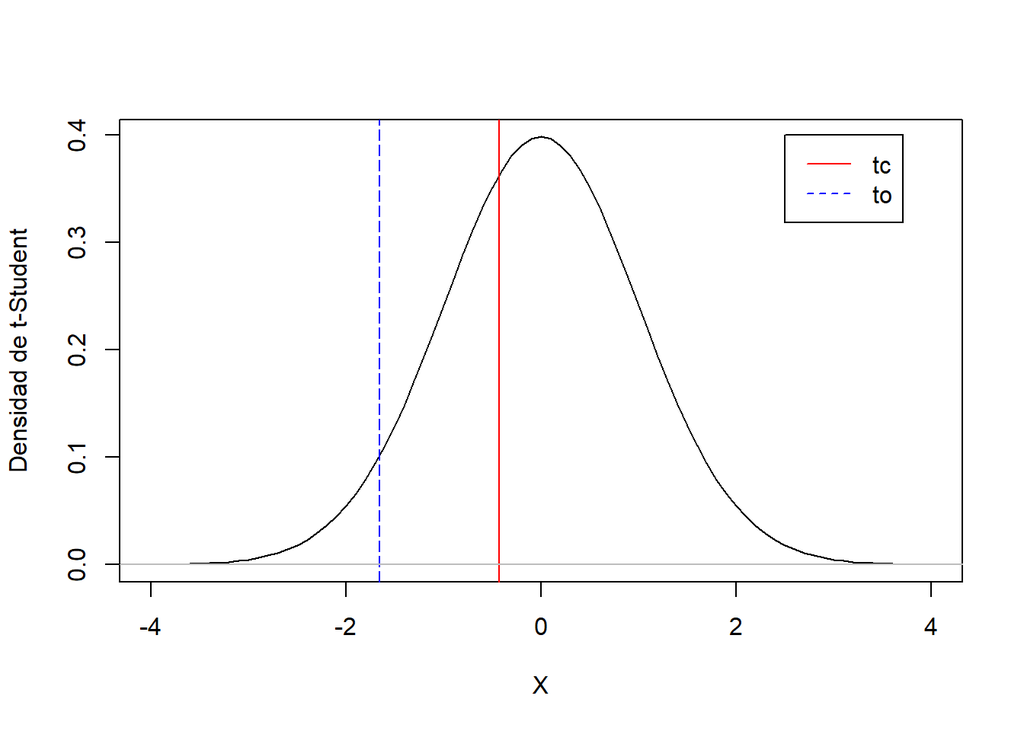

### Hipótesis 3:

#### INTERVALO DE CONFIANZA PARA LA MEDIA:

El intervalo de confianza es un par de números entre los cuales se estima que puede estar cierto valor desconocido respecto a un parámetro poblacional con un determinado nivel de confianza. En este caso determinaremos el intervalo de confianza de dos variables, la primera “Horas_trabajo” y la segunda “Horas_estudio”. Estos dados han sido obtenidos a través de una encuesta realizada a una muestra poblacional de los estudiantes de UTEC.

### VARIABLE Horas_trabajo:

Intervalo inferior:

```r
media1-(qt(1-alfa/2, n1-1)*(s1/sqrt(n1)))
```

```
## [1] 5.47877
```

Intervalo superior:

```r
media1+(qt(1-alfa/2, n1-1)*(s1/sqrt(n1)))
```

```
## [1] 6.672174
```

Como vemos, la media de las horas que trabajan los estudiantes en vacaciones varia entre las 5.48 y 6.67 horas. Siendo el intervalo de confianza de (5.48; 6.67) horas.

### VARIABLE Horas_estudio:

Intervalo inferior:

```r
media2-(qt(1-alfa/2, n2-1)*(s2/sqrt(n2)))
```

```
## [1] 3.700536
```

Intervalo superior:

```r
media2+(qt(1-alfa/2, n2-1)*(s2/sqrt(n2)))
```

```
## [1] 4.50816
```

### Hipótesis:

Evaluaremos si la media de los estudiantes de UTEC trabajan en las vacaciones a lo máximo 6 horas diarias. Para esta prueba de hipótesis utilizaremos la variable “Horas_trabajo”.

### Parámetros del estudio:

- Nivel de confianza= 95%
- error=5%
- Variable: DF$Horas_trabajo
- Prueba de hipótesis: unilateral con cola hacia la derecha t2 = t(1-fi, n-1)
- Estimador puntual: Media

Hipótesis nula: EL promedio de las horas de trabajo de los estudiantes de UTEC en vacaciones es a lo máximo 6 horas diarias.

Hipótesis alternativa: El promedio de las horas de trabajo de los estudiantes de UTEC en vacaciones es mayor a 6 horas diarias.

#### Resultados de la hipótesis:

```
## [1] 0.2538035
```

```
## [1] 1.674689
```

#### Gráfico:

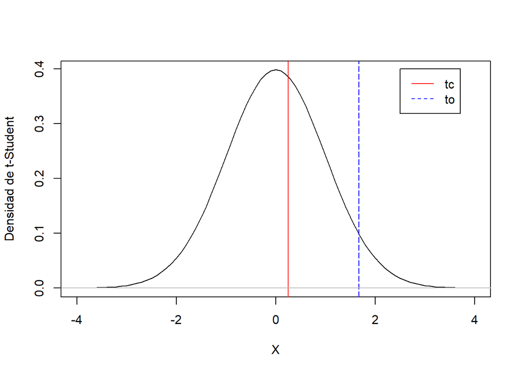

```r
X <- seq(-4, 4, by = 0.1)
plot(X, dt(X,df=n-1), type = "l",ylab="Densidad de t-Student")
abline(v=tc, lty = c(1,2), col = "red")
abline(v=to, lty = c(5,5), col = "blue")
abline(h = 0, col = "gray")
legend(2.5,0.4,c("tc","to"),col=c("red","blue"), lty = c(1,2))
```

#### Observaciones:

- Utilizamos la mediana para determinar un punto donde la media de horas que los estudiantes dedican para trabajar sea máximo.
- La región de aceptación se encuentra en el rango to <= 1.6747 Nuestro resultado nos da que tc = 0.2538, el cual es mejor a to = 1.6747. Esto nos indica indica que tc se encuentra en la región de aceptación por lo que la hipótesis nula (*Ho*) será aceptada.
- La media de los estudiantes de UTEC que trabajaron en las vacaciones llega a lo máximo a 6 horas diaria.

### Hipótesis 4:

### Hipótesis planteadas:

1. El promedio del IMC es mayor o igual a la media.
2. A mayor peso el IMC aumenta.
3. Que la media del IMC es mayor o igual 23.05 .

```r
#26.15 es el IMC promedio nacional del Perú
DF9 <- DFT %>% group_by(IMC) %>% summarise(peso)
```

[output not shown]

### Parámetros del estudio:

- Confianza: 95%
- Significancia: 5%
- Variable: IMC
- Prueba de hipótesis: Unilateral izquierda
- Estimador puntual: Media
- Modelo: t-Student
- *Ho*= El promedio del IMC tiene un valor mayor o igual a 23.05.
- *H1*= El promedio del IMC tiene un valor menor a 23.05.

#### Resultados de la hipótesis

```r
media<-mean(DF9$IMC, na.rm = TRUE)
s<-sd(DF9$IMC, na.rm = TRUE)
n<-nrow(DF9)-sum(!complete.cases(DF9$peso))
sig<-0.05
to<-qt(sig,n-1)
to
```

```
## [1] -1.654874
```

```r
tc <- (media-23.05)/(s/sqrt(n))
tc
```

```
## [1] 2.133231
```

### Intervalo de confianza

```
## [1] 23.0951
```

```
## [1] 23.66027
```

```
## [1] 24.22545
```

### *Resultados de la hipótesis 4*

```r
to<-qt(sig,n-1)
to
```

```
## [1] -1.654874
```

```r
tc <- (media- 23.66)/(s/sqrt(n))
tc
```

```
## [1] 0.0009495595
```

```r
# Aceptamos el H0
```

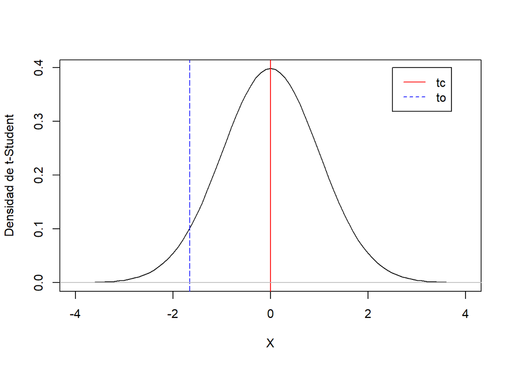

```r
X <- seq(-4, 4, by = 0.1)
plot(X, dt(X,df=n-1), type = "l",ylab="Densidad de t-Student")
abline(v=tc, lty = c(1,2), col = "red")
abline(v=to, lty = c(5,5), col = "blue")
abline(h = 0, col = "gray")
legend(2.5,0.4,c("tc","to"),col=c("red","blue"), lty = c(1,2))
```

## Regresiones

#### Peso VS. IMC

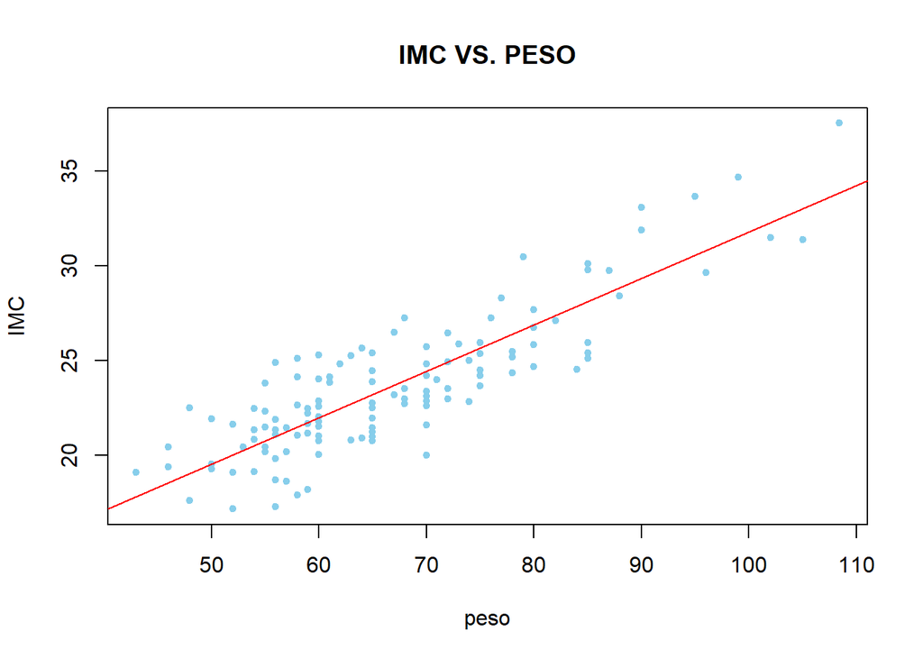

```r
plot(DFT$peso,DFT$IMC, pch=20, main = "IMC VS. PESO", xlab="peso", ylab = "IMC",col="skyblue")
abline(Lm1,col="red")
```

```r
summary(Lm1)
```

```
##
## Call:
## lm(formula = DFT$IMC ~ DF$peso)
##
## Residuals:
##     Min      1Q  Median      3Q     Max
## -4.4324 -1.2190 -0.2278  1.2392  3.8680
##
## Coefficients:
##             Estimate Std. Error t value Pr(>|t|)
## (Intercept)   7.3037     0.8080   9.039 6.84e-16 ***
## DF$peso       0.2450     0.0119  20.589  < 2e-16 ***
## ---
## Signif. codes:  0 '***' 0.001 '**' 0.01 '*' 0.05 '.' 0.1 ' ' 1
##
## Residual standard error: 1.83 on 152 degrees of freedom
## Multiple R-squared:  0.7361, Adjusted R-squared:  0.7343
## F-statistic: 423.9 on 1 and 152 DF,  p-value: < 2.2e-16
```